# Tidyverse Vignette: Preparing online data for facet_wrap

# Visualization of Tall Data

The data frame now has columns for age group and corresponding values for the three years surveyed. As a final step, lets look at a specific use pattern and compare the bar plots for each age group.

```r
#call our function that has the new columns
drug_abuse_lifetime <- drug_abuse_tall %>%
  #start by looking at lifetime use, and any illicit drug use
  filter(Time.Period == 'Lifetime', Drug == 'Illicit Drugs') %>%
  #Gather the percentages, assigning them to the new 'Percent' column, also split each observation by year
  gather(Year, Percent, 'Percent Use, 2016':'Percent Use, 2018') %>%
  #edit the 'Year' column so that it omits the 'Percent Use' string
  separate(Year, c(NA, "Year"), sep = ",", convert = TRUE)
head(drug_abuse_lifetime)
```

|  | Drug | Time.Period | Age_Group | Year | Percent |
| --- | --- | --- | --- | --- | --- |
| 1 | Illicit Drugs | Lifetime | Ages.12.or.Older | 2016 | 48.5 |
| 2 | Illicit Drugs | Lifetime | Ages.12.to.17 | 2016 | 23.0 |
| 3 | Illicit Drugs | Lifetime | Ages.18.to.25 | 2016 | 56.3 |
| 4 | Illicit Drugs | Lifetime | Ages.26.or.Older | 2016 | 50.2 |
| 5 | Illicit Drugs | Lifetime | Ages.12.or.Older | 2017 | 49.5 |
| 6 | Illicit Drugs | Lifetime | Ages.12.to.17 | 2017 | 23.9 |

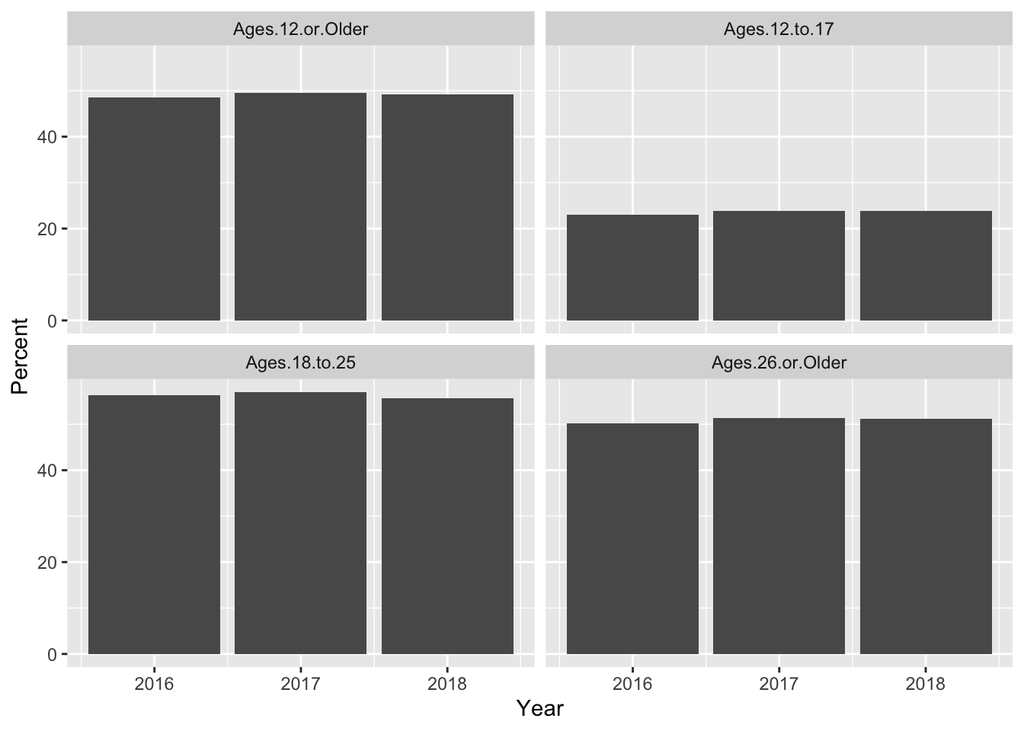

```r
library(ggplot2)
plot_drug_abuse <- drug_abuse_lifetime %>%
  #call ggplot, plot year versus prevalence in terms of percent
  #stat = 'identity' sets the bars equal to the percent magnitude instead of the frequency of values
  ggplot(aes(x= Year, y = Percent)) + geom_bar(stat = "identity") +
  #call facet_wrap function, specify the variable to wrap as the four age groups
  facet_wrap(~Age_Group)

plot_drug_abuse
```

# Conclusion

The function facet_wrap is a useful tool for comparing plots over several variables on the same scale. Tidyverse fucntions make it easy to gather data into the correct format to visualize many different comparisons.